# ANOVA Example - Tooth Growth in Guinea Pigs

Taylor Grimm

# Dataset

For this analysis, I will be using the `ToothGrowth` dataset. This dataset is a part of base R and can be seen by simply typing `ToothGrowth` into the console window. Below is the description of this dataset provided by typing `?ToothGrowth`:

> “The response is the length of odontoblasts (cells responsible for tooth growth) in 60 guinea pigs. Each animal received one of three dose levels of vitamin C (0.5, 1, and 2 mg/day) by one of two delivery methods, orange juice or ascorbic acid (a form of vitamin C and coded as VC).”

We can now load in any packages we’ll be using and set up the data so it can be used for plotting and analysis.

```r
library(tidyverse)
library(kableExtra)

# We can use the data() function to load the ToothGrowth dataset into our global environment
data('ToothGrowth')

# Dose is initially listed as a numeric (double) vector, but for the purposes of our analysis we want dose to be a factor variable
ToothGrowth$dose <- as.factor(ToothGrowth$dose)
```

Now, let’s look at a few random rows of the dataset to make sure everything is loaded in properly. The `kableExtra` package gives us a nice way to make tables in RMarkdown that will be visually appealing in HTML (and other) formats, and `slice_sample()` from the `dplyr` package (part of the `tidyverse`) lets us easily select 10 random rows from the dataset to view:

```r
ToothGrowth %>% as_tibble() %>% slice_sample(n = 10) %>% kable() %>% kable_minimal()
```

| len | supp | dose |
| --- | --- | --- |
| 11.2 | VC | 0.5 |
| 18.5 | VC | 2 |
| 16.5 | OJ | 0.5 |
| 6.4 | VC | 0.5 |
| 27.3 | OJ | 2 |
| 15.2 | OJ | 0.5 |
| 32.5 | VC | 2 |
| 10.0 | OJ | 0.5 |
| 25.5 | VC | 2 |
| 17.3 | VC | 1 |

# Exploratory Data Analysis

## Boxplots for Explanatory Variables

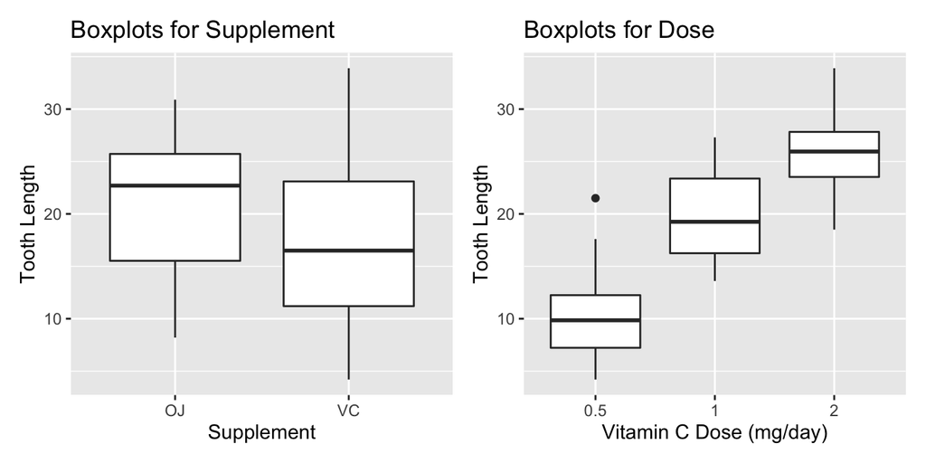

```r
library(patchwork)

# Boxplots for Supplement and for Dose (separate)
supp_boxplots <- ToothGrowth %>%
  ggplot(aes(supp, len)) +
  geom_boxplot() +
  xlab("Supplement") +
  ylab("Tooth Length") +
  ggtitle("Boxplots for Supplement")

dose_boxplots <- ToothGrowth %>%
  ggplot(aes(dose, len)) +
  geom_boxplot() +
  xlab("Vitamin C Dose (mg/day)") +
  ylab("Tooth Length") +
  ggtitle("Boxplots for Dose")

supp_boxplots + dose_boxplots
```

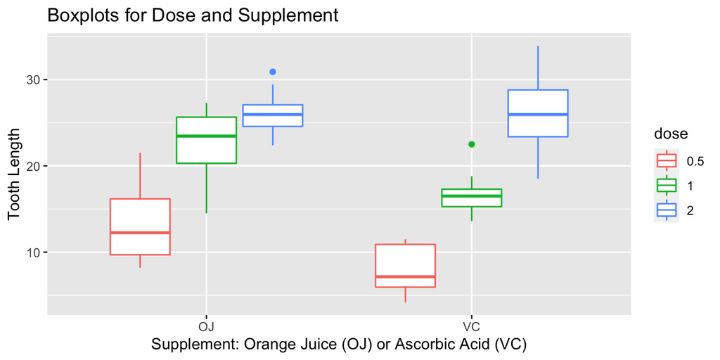

```r
# Boxplots of Dose by Supplement
ToothGrowth %>%
  ggplot(aes(supp, len, col = dose)) +
  geom_boxplot() +
  xlab("Supplement: Orange Juice (OJ) or Ascorbic Acid (VC)") +
  ylab("Tooth Length") +
  ggtitle("Boxplots for Dose and Supplement")
```

## Test for Homogeneity of Variance

```r
# Test for homogeneity of variance
car::leveneTest(len ~ supp*dose, data = ToothGrowth)
```

```
## Levene's Test for Homogeneity of Variance (center = median)
##       Df F value Pr(>F)
## group  5  1.7086 0.1484
##       54
```

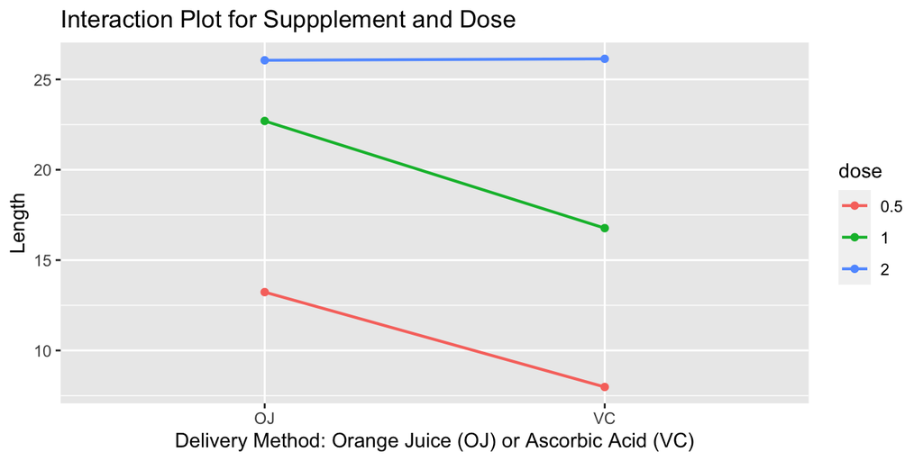

```r
ToothGrowth %>%
  group_by(supp, dose) %>%
  summarise(mean_len = mean(len)) %>%
  ggplot(aes(supp, mean_len)) +
  geom_line(size = .75, aes(group = dose, color = dose)) +
  geom_point(aes(col = dose)) +
  ylab("Length") +
  xlab("Delivery Method: Orange Juice (OJ) or Ascorbic Acid (VC)") +
  ggtitle("Interaction Plot for Suppplement and Dose")
```

# Two-way ANOVA Model

The two-way ANOVA model is as follows:

$$y_{ijk} = \mu + \alpha_i + \beta_j + (\alpha\beta)_{ij} + \epsilon_{ijk},$$
where $y_ijk$ represents the recorded tooth length of each guinea pig, $\mu$ represents the grand mean, $\alpha_i$ represents the supplement effect with $i \in \{\textrm{OJ, VC}\}$, $\beta_j$ is the dose effect with $j \in \{0.5, 1, 2\}$, $(\alpha\beta)_{ij}$ is the interaction between supplement and dose at levels $i$ and $j$, and $\epsilon_{ijk}$ is the error term for supplement $i$, dose $j$, and observation $k$.

# Assumptions

- Independent observations
- Normality
- Equal variance

# Model Fitting and Checking Assumptions

```r
model1 <- lm(len ~ supp*dose, data = ToothGrowth)
```

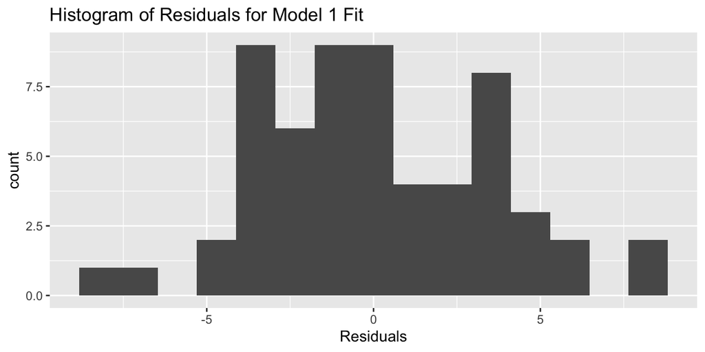

```r
# Fit model
model1 <- lm(len ~ supp*dose, data = ToothGrowth)

# Check model assumptions

# Independence
# We assume the animals are independent of one another and that the tooth growth of one guinea pig is unrelated to the tooth growth of another.

# Normality
ggplot() +
  geom_histogram(aes(resid(model1)), bins = 15) +
  xlab("Residuals") +
  ggtitle("Histogram of Residuals for Model 1 Fit")
```

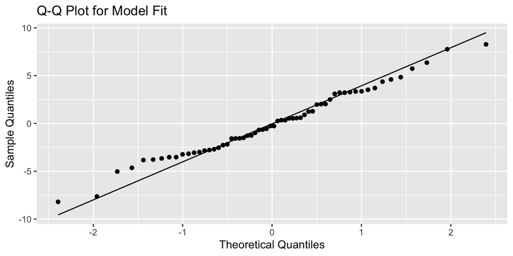

```r
ggplot(mapping = aes(sample = resid(model1))) +
  geom_qq() +
  geom_qq_line() +
  xlab("Theoretical Quantiles") +
  ylab("Sample Quantiles") +
  ggtitle("Q-Q Plot for Model Fit")
```

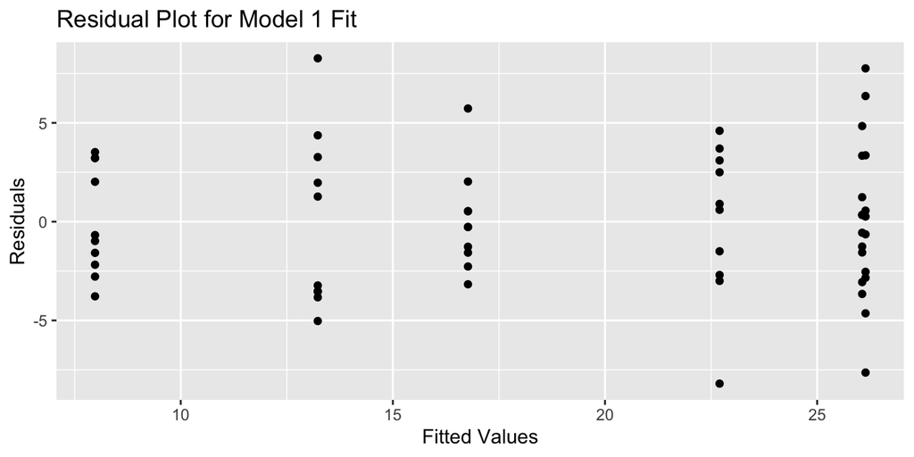

```r
# Equal variance
ggplot() +
  geom_point(aes(fitted(model1), resid(model1))) +
  xlab("Fitted Values") +
  ylab("Residuals") +
  ggtitle("Residual Plot for Model 1 Fit")
```